# ONA_Exercise 2_Amr Maraqa

2023-03-21

```r
library(dplyr)
library(tidyr)
library(tidyverse)
```

```r
library(igraph)
library(tidygraph)
library(ggraph)
# Create Data
nodes <- c('A', 'B', 'C', 'D', '1', '2', '3', '4', '5', '6')
front <- c('2', 'A', NA, 'B',NA, '1', 'C', NA, 'D', NA)
back <- c('B', 'D', '3', '5', '2', 'A', NA, NA, NA, NA)
right <- c(NA, 'C', NA, '3', NA, NA, '4', NA, NA, 'D')
left <- c(NA, NA, 'B', '6', NA, NA, 'D', '3', NA, NA)
NE <- c('C', '3', '4', NA, NA, NA, NA, NA, NA, '5')
SE <- c(NA, NA, NA, 'C', NA, NA, NA, NA, '3', 'B')
NW <- c(NA, '6', 'D', NA, NA, NA, '5', NA, NA, NA)
SW <- c(NA, NA, 'A', NA, NA, NA, 'B', 'C', '6', NA)
seats_df <- cbind(nodes, front, back, right, left,NE,SE,NW,SW)

# Define nodes and edges
edges <- rbind(as.data.frame(cbind(nodes, front)) %>% rename(c('to' = front, 'from' = nodes)),
               as.data.frame(cbind(nodes, back)) %>% rename(c('to' = back, 'from' = nodes)),
               as.data.frame(cbind(nodes, right)) %>% rename(c('to' = right, 'from' = nodes)),
               as.data.frame(cbind(nodes, left)) %>% rename(c('to' = left, 'from' = nodes)),
               as.data.frame(cbind(nodes, NE)) %>% rename(c('to' = NE, 'from' = nodes)),
               as.data.frame(cbind(nodes, SE)) %>% rename(c('to' = SE, 'from' = nodes)),
               as.data.frame(cbind(nodes, NW)) %>% rename(c('to' = NW, 'from' = nodes)),
               as.data.frame(cbind(nodes, SW)) %>% rename(c('to' = SW, 'from' = nodes)))

edges <- edges %>% drop_na()
nodes <- as.data.frame(nodes)
colnames(nodes) <- c('node')
```

```r
# Create Network
network <- tbl_graph(nodes = nodes, edges = edges, directed=FALSE)
```

```r
# Calculating node metrics
network <- network %>%
  mutate(degree = centrality_degree()/2,
         closeness = centrality_closeness_harmonic(),
         betweenness = centrality_betweenness()) %>%
  mutate(avg = (degree + closeness + betweenness)/3) %>%
  mutate(label = paste0(node, '\n',
                        'Degree: ',round(degree,2), '\n',
                        'Closeness: ',round(closeness,2), '\n',
                        'Betweenness: ',round(betweenness,2), '\n',
                        'Avg: ',round(avg,2)))
net_data <- network %>% data.frame() %>% tibble()
```

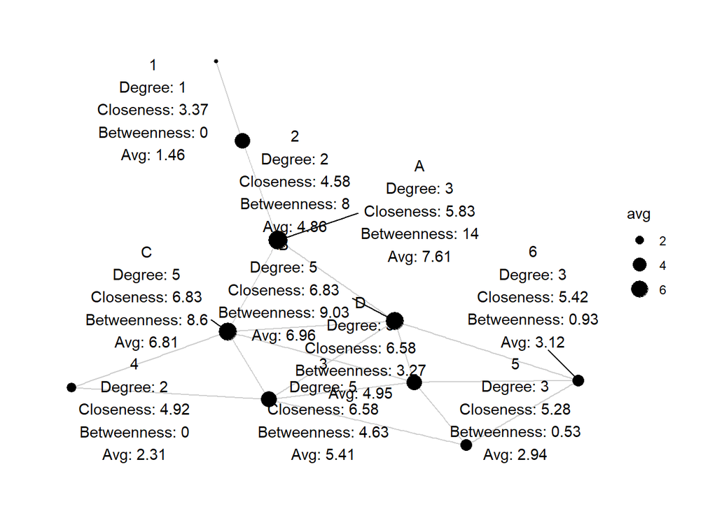

```r
# Plot Network
network %>%
  ggraph(layout="graphopt") +
  geom_edge_link(edge_colour = "grey", alpha=0.5) +
  geom_node_point(aes(size=avg)) +
  geom_node_text(aes(label = label), repel=TRUE) +
  theme_graph(foreground=NA)
```

Seat Choice and Explanation

I would choose to sit in seat B on the fakebook bus. Even though my average score on that seat wouldn’t be the highest (seat A avg = 7.61), I would have the highest degree and measure of closeness in the network.This means that seat B would allow me to be the most popular among the Fakebook interns and to form strong relationships with them as well. Although the person sitting in seat A would have a higher measure of betweenness than I would, seat B would still give me access to many friend circles on the bus. One of the drawbacks of my choice is it reliance on the person in seat A for conncection with those in seats 1 and 2, as he/she would be the only link between me and them. If those sitting in seats 1 and 2 happen to be crucial to my role or future in a way (group leader, well-connected), I would be greatly disadvantaged to be in seat B, because my access to the people in seat 1 and 2 would be subject to the unpredicatability of the behavior of the person in seat A.